# Zvočni objem: neposredni perceptualni učinki umetniških zvočnih kompozicij na doživljanje tinitusa

Eksploratorna mešano-metodološka analiza

Boštjan Simon, Zavod TINITUS

21. June 2026

# 1 Povzetek

Pričujoče poročilo predstavlja eksploratorno analizo perceptualnih učinkov osmih umetniških zvočnih kompozicij (“zvočnih kopeli”), izvedenih v okviru projekta *Zvočni objem* (Zavod TINITUS, februar–april 2026, Glasbena šola Nova Gorica). Vsako kopel je sestavljala tridelna kompozicija avtorja Boštjana Simona, ki je združevala načela zvočnega prekrivanja tinitusa (frekvenčna izhodišča je svetovala dr. Branka Getzy, ORL) z umetniško zasnovo, ki preprečuje monotonijo običajnih maskerjev.

Ker gre za eksploratorno študijo brez kontrolne skupine, brez longitudinalnega sledenja in brez naključnega vzorčenja, so vse navedene številke deskriptivne; sklepov o učinkovitosti zvočne kopeli kot terapevtske intervencije iz njih ni mogoče izpeljati. Namen poročila je: (1) opisati doživljanje udeleženk in udeležencev med posameznimi deli kompozicij, (2) prepoznati zvočne elemente, ki so v perceptualnem smislu prinašali olajšanje ali poslabšanje, ter (3) ponuditi osnovo za zasnovo prihodnjih nadzorovanih raziskav.

# 2 Uvod

Tinitus je pogosta slušna izkušnja: prizadene približno desetino splošne populacije. Ozdravitve ni; obvladovanje simptoma temelji predvsem na zvočnem prekrivanju, kognitivno-vedenjski terapiji in prilagoditvi vsakdanjih navad.

Klasični zvočni maskerji (beli šum, posnetki narave) so za del oseb učinkoviti, a imajo dve znani slabosti: monotonost in habituacijo. Po daljši izpostavljenosti se njihov maskirni učinek zmanjša, hkrati pa lahko postanejo moteči. Pričujoči projekt zato preverja drugačno možnost: ali lahko **umetniško komponirani zvok**, ki ohranja maskirno funkcijo in hkrati uvaja estetsko in dinamično raznolikost, ponudi alternativen pristop.

Pomembno je razumeti, *kaj* projekt **ne** preučuje: ne dolgotrajne učinkovitosti, ne fizioloških sprememb in ne kliničnih izhodov. Pozornost je usmerjena izključno na **neposredne, znotraj-sejne perceptualne učinke** posameznih delov kompozicij.

# 3 Raziskovalna vprašanja

**Primarna:**

1. Kateri deli umetniških zvočnih kompozicij so povezani z zaznano **olajšavo** tinitusa?
2. Kateri deli so povezani s **poslabšanjem** zaznave tinitusa?
3. Kako udeleženci ocenjujejo **estetsko/afektivno doživetje** (prijetnost) po delih?

**Sekundarna (eksploratorna):**

4. Ali se vzorci odgovorov razlikujejo glede na **podtip tinitusa** (piskanje, šumenje, brenčanje, bobnenje)?
5. Ali se razlikujejo glede na **resnost simptoma** ali **prejšnje izkušnje z zvočnimi maskerji**?
6. Kako kvalitativni opisi izkušnje **kontekstualizirajo** numerične ocene?
7. Ali sta **prijetnost in olajšanje** med sabo povezana – ali “všečno” pomeni tudi “manj tinitusa”?

Pred začetkom študije ni bilo postavljenih nobenih hipotez; vse analize so deskriptivne.

# 4 Metode

## 4.1 Tip študije

Eksploratorna, mešano-metodološka, **presečna opazovalna študija s ponovljenim vzorčenjem**. Vsaka seja je obravnavana kot samostojen dogodek zbiranja podatkov; **enota analize je odgovor v posamezni seji** (person-session response), ne posameznik v daljšem časovnem obdobju.

Razlogi za tako zasnovo:

- maksimizira izrabo podatkov ob nihajočem obisku,
- se izogne odhodu udeležencev (attrition) tipičnemu za longitudinalne načrte,
- ustreza raziskovalnim vprašanjem o *neposrednih* (ne kumulativnih) učinkih,
- znižuje breme sodelovanja,
- omogoča anonimno zbiranje (brez sledljivih identifikatorjev).

**Kompromisi:** ne moremo oceniti kumulativnih ali individualnih učinkov, ne moremo strogo upoštevati korelacije ponovljenih meritev pri istih osebah, ne moremo opisati osebnih trajektorij. Nekaj udeležencev je verjetno prispevalo več opazovanj; v primarni analizi so ta obravnavana neodvisno (znana omejitev, obravnavana spodaj).

## 4.2 Intervencija

Skupinske zvočne kopeli avtorja Boštjana Simona, izvedene v živo. Vsaka kopel je trajala približno 60 minut in je bila razdeljena na **tri približno enako dolge dele**: PRVI DEL, DRUGI DEL in TRETJI DEL. Kompozicije so povezovale načela zvočnega prekrivanja (frekvence po nasvetu dr. B. Getzy) z umetniškimi prijemi, ki uvajajo dinamično in tekstualno raznolikost. Mestoma je nastopalo živo izvajanje saksofona, mestoma elektronski material in posnetki narave.

**Razpored.** Osem tedenskih sej, 24. februar – 14. april 2026. **Prizorišče.** Velika dvorana, Glasbena šola Nova Gorica.

## 4.3 Naknadno kodiranje zvočne vsebine

Po zaključku zbiranja podatkov je avtor (B. Simon) v prosti obliki opisal zvočno vsebino vsakega od 24 delov (osem sej x trije deli). Iz teh opisov je bila izpeljana **binarna kodirna shema** z dvema kategorijama elementov:

- **Glasbeni elementi** (akordi, sekvence, drone, gamelan, kalimba, klarinet, saksofon, ritmika, sintetska melodija, gongi ipd.) — 12 različnih elementov.
- **Elementi prekrivanja** (črički, beli šum, voda, dež, ptiči, prasketanje vinila, kraguljčki, terenski posnetki ipd.) — 13 različnih elementov.

**Pomembna omejitev.** Kodiranje je bilo izvedeno **naknadno (post hoc)** in s strani **istega avtorja, ki je kompozicije izvajal**. To predstavlja možno sistematično pristranskost; analize na ravni elementov je treba obravnavati zgolj kot deskriptivne in hipotetske, ne kot dokazovanje učinkovitosti posameznih zvočnih sestavin.

**Splošna opomba avtorja.** Moduliran beli šum je bil dodajan in odvzemal skozi celotno sejo, v približno 15-minutnih sklopih, kar pomeni, da gre za skoraj vseprisotno komponento. Eksplicitno je zato kodiran le v delih, kjer ga je avtor izrecno omenil kot dominantni element prekrivanja.

## 4.4 Udeleženci

Odprto vabilo prek socialnih omrežij (Društvo Tinitus), brez formalnega presejanja poleg samoporočanega tinitusa in starostne meje 18 let. Edina previdnost je veljala za osebe s hudo hiperakuzijo (individualno odsvetovano). Pisno informirano soglasje je bilo pridobljeno ob prvem obisku.

## 4.5 Vprašalnik

Enostranski papirni vprašalnik je bil izpolnjen ob vsaki seji.

**Pred sejo (ob prihodu):**

1. Pogostost tinitusa: stalno / občasno.
2. Tip tinitusa (večodgovorno): piskanje / šumenje / brenčanje / bobnenje / drugo.
3. Resnost v vsakdanjem življenju (5-stopenjska lestvica): sploh me ne moti … ekstremno moteč.
4. Prejšnja uporaba zvočnih maskerjev (4-stopenjska lestvica): nikoli, enkrat, večkrat, redno.

**Po vsakem delu (3×):**

- Afektivna valenca (0–10): zelo neprijetno … zelo prijetno.
- Vpliv na tinitus (0–10): opazno poslabšanje … opazno olajšanje (5 = ni spremembe).
- Odprto besedilo: opis izkušnje.

**Po koncu seje:**

5. Splošno doživetje (5-stopenjska emoji lestvica).
6. Zavedanje tinitusa med kopeljo (tristopenjsko): sploh ne / včasih / tekom celotne kopeli.

## 4.6 Etični vidiki

Informirano soglasje, pojasnjeno, da gre za raziskavo in ne za zdravstveno obravnavo, možnost umika kadar koli, brez zbiranja identifikacijskih podatkov v samem vprašalniku, obdelava skladno z GDPR. Sofinancer (Asociacija) je nadziral projekt; formalne presoje s strani etične komisije nismo izvajali, kar je v slovenskem kontekstu raziskav umetnost-zdravje ustaljena praksa za pilotne študije.

## 4.7 Analitični pristop

Vse kvantitativne analize so **deskriptivne in eksploratorne**. Inferenčnih testov ne uporabljamo za potrditev hipotez, ker (a) hipotez ni bilo, (b) oblikovni omejitvi (samoizbira, brez kontrolne skupine, ponovljene meritve istih oseb brez identifikatorja) onemogočata kavzalno sklepanje, in (c) podvzorci so za posamezne podskupine premajhni za smiselno statistično moč.

Kjer kljub temu poročamo o povezavah (npr. Spearmanov $\rho$ med prijetnostjo in vplivom), to služi le **kvantifikaciji opisne povezanosti**, brez sklepov o kavzalnosti ali pomembnosti.

Kvalitativna analiza prostih opisov temelji na frekvenčni analizi lem s pomočjo slovenskega modela UDPipe (jezikovni model SSJ). Štiri vrstice z italijanskimi odgovori so iz besedilne analize izključene do prevoda; po prevodu se analiza ponovi brez sprememb v kodi.

**Programska oprema.** R 4.5, samo osnovna grafika za statične grafe; interaktivni Sankey-jevi diagrami so prikazani s pomočjo paketa `networkD3` (JavaScript v ozadju). Vsa analiza je verzionirana in reproducibilna; izvorna koda je priložena.

# 5 Rezultati

## 5.1 Opis vzorca

Število izpolnjenih vprašalnikov po sejah.

| Seja | Datum | N odgovorov |
| --- | --- | --- |
| I | 24. 2. | 21 |
| II | 3. 3. | 16 |
| III | 10. 3. | 15 |
| IV | 17. 3. | 14 |
| V | 24. 3. | 14 |
| VI | 31. 3. | 11 |
| VII | 7. 4. | 8 |
| VIII | 14. 4. | 19 |

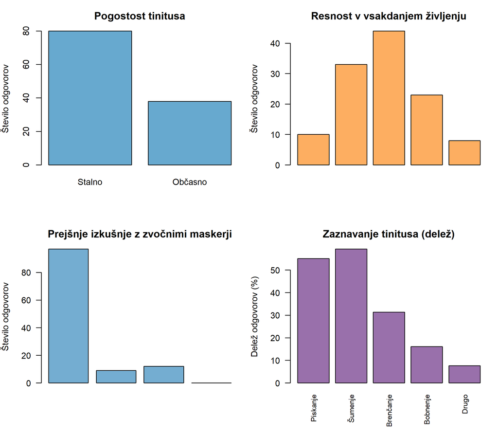

Opis vzorca: pogostost tinitusa, resnost, prejšnje izkušnje z maskerji, podtipi.

## 5.2 Splošno doživetje seje (Q5, Q6)

Splošna ocena prijetnosti seje (Q5; -2 = zelo neprijetno, +2 = zelo prijetno; vmesne vrednosti pri dvojnih oznakah).

|  | Ocena | N |
| --- | --- | --- |
| 1 | -2 | 1 |
| 3 | -1 | 5 |
| 5 | 0 | 11 |
| 6 | 0.5 | 1 |
| 7 | 1 | 49 |
| 8 | 1.5 | 2 |
| 9 | 2 | 47 |

Zavedanje tinitusa med kopeljo (Q6).

| Stopnja | N |
| --- | --- |
| Sploh ne | 28 |
| Včasih | 57 |
| Tekom celotne kopeli | 32 |

## 5.3 Doživetje po posameznih delih

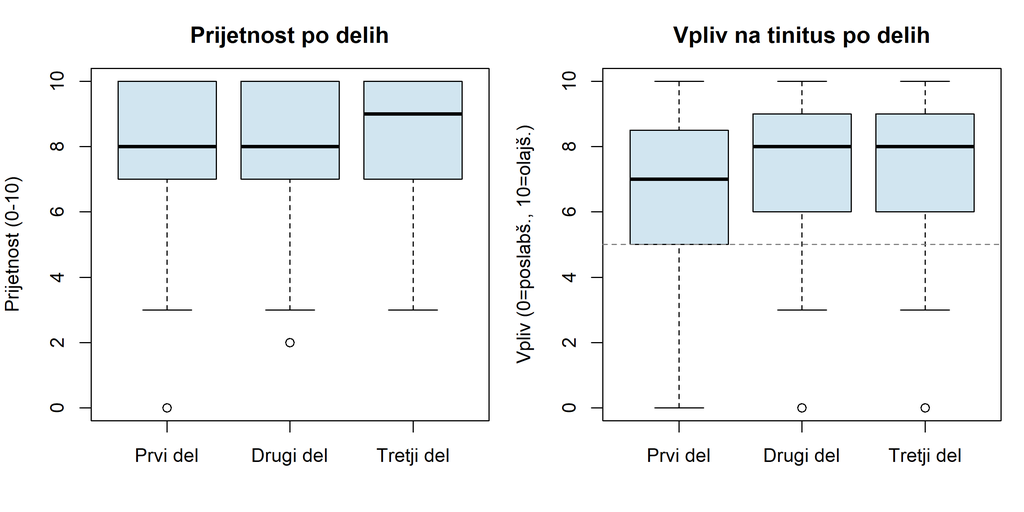

Porazdelitev ocen prijetnosti (levo) in vpliva na tinitus (desno) po treh delih kompozicije. Črtkana črta na desnem grafu označuje nevtralno raven (5 = brez spremembe).

## 5.4 Vzorci po sejah (heatmapi)

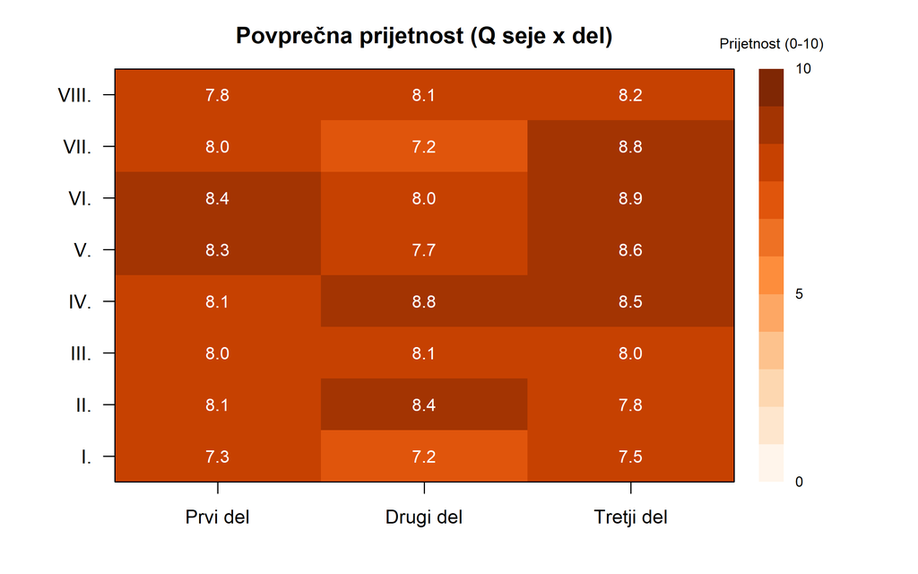

Povprečna ocena prijetnosti po seji in delu.

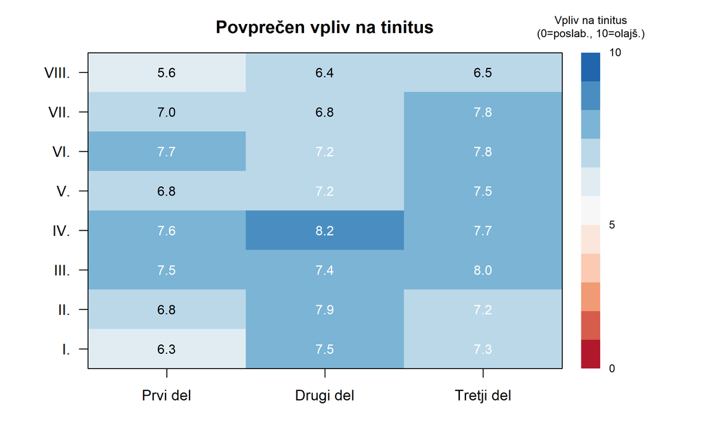

Povprečna ocena vpliva na tinitus po seji in delu. Vrednosti nad 5 nakazujejo olajšanje, pod 5 poslabšanje.

## 5.5 Analiza po zvočnih elementih

Heatmapi v §5.4 prikazujejo povprečja na ravni *seja x del*. Tukaj povprečja razdeljujemo po **zvočnih sestavinah**, kot jih je naknadno kodiral avtor kompozicij (glej §4.3 za omejitve). Cilj je dveh vrst: (1) prepoznati elemente, ki so pri poslušalcih povezani z razmeroma višjim oziroma nižjim povprečnim vplivom na tinitus, in (2) preveriti, ali se kodiranje avtorja prekriva z besedami, ki jih udeleženci uporabljajo v prostih opisih.

### 5.5.1 Povprečen vpliv in prijetnost po elementu

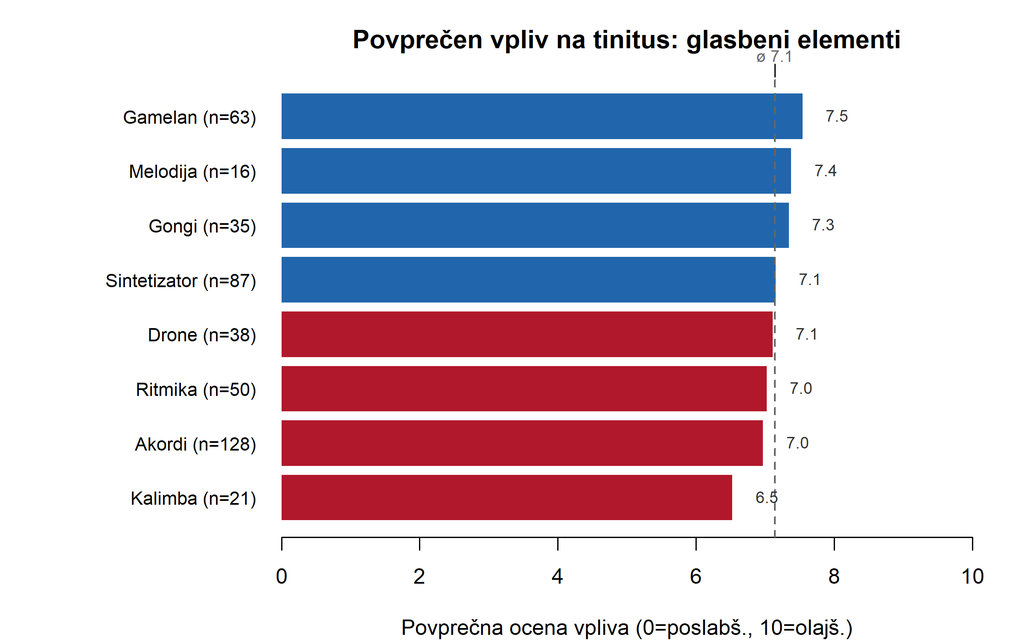

Povprečen vpliv na tinitus po glasbenih elementih. Modra: nad globalnim povprečjem; rdeča: pod njim. Črtkana črta označuje globalno povprečje. Elementi s prisotnostjo v vsaj 2 delih.

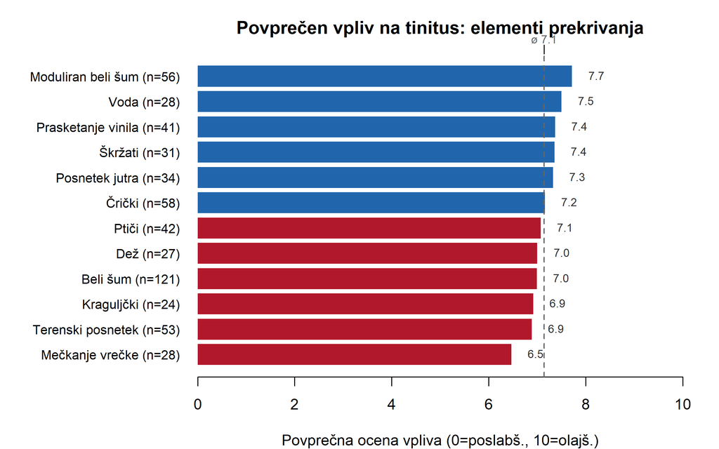

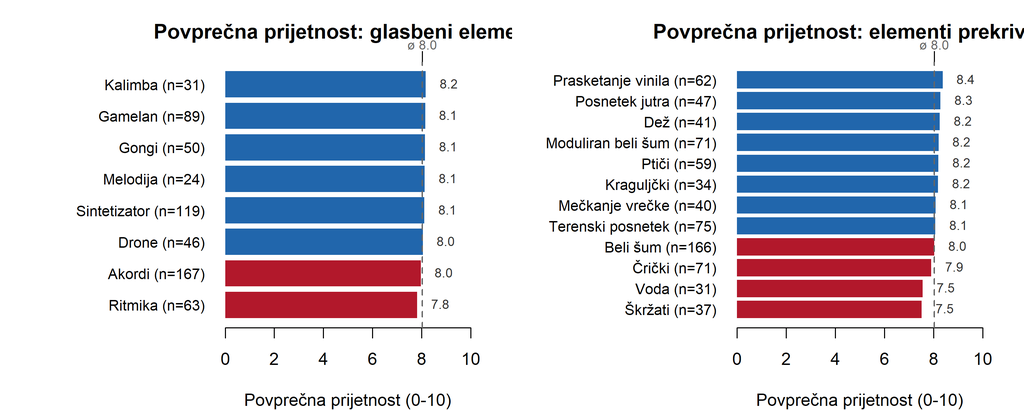

Povprečna prijetnost po elementih. Razpon je ozek (vse vrednosti med 7,5 in 8,5), kar nakazuje, da so udeleženci skoraj univerzalno ocenili kopeli kot prijetne, ne glede na specifične zvočne sestavine.

### 5.5.2 Skladnost avtorjevega kodiranja z opisi udeležencev

Spodnji graf prikazuje za vsak element, ki ima jasno besedno signaturo (npr. *dež*, *ptiči*, *voda*), kolikšen delež prostih opisov ga eksplicitno omenja — ločeno za dele, kjer je avtor element označil kot prisoten, in za dele, kjer ga ni.

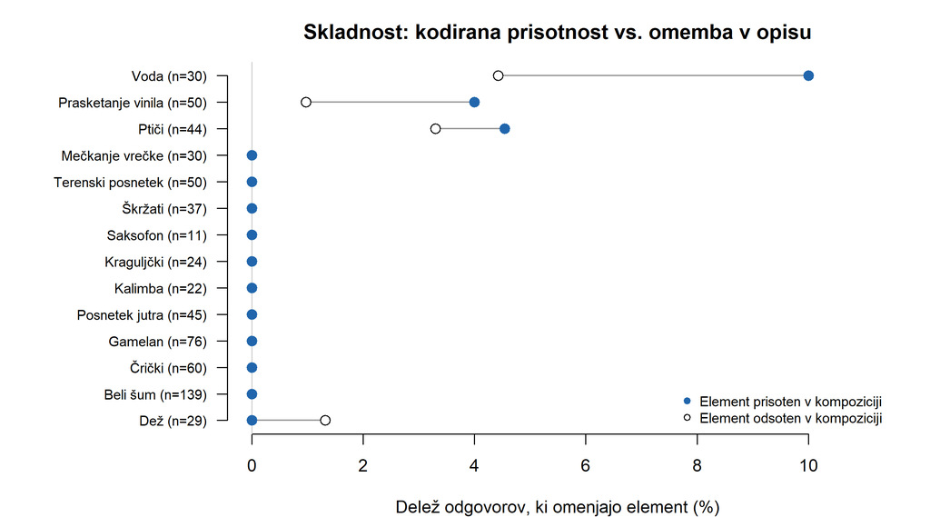

Skladnost med kodirano prisotnostjo elementa in njegovo eksplicitno omembo v opisih udeležencev. Modre pike: element prisoten v delu; bele pike: element odsoten. Razlika med pikama je ‘specifičnost zaznave’.

## 5.6 Razlike po podskupinah

Spodnji grafi prikazujejo porazdelitve po posameznih delih, ločeno po podtipu tinitusa, resnosti in prejšnjih izkušnjah z maskerji. Iz razlogov, opisanih v §4.7 (premajhne podskupine, ponovljene meritve istih oseb), v poročilu ne izvajamo formalnih primerjav.

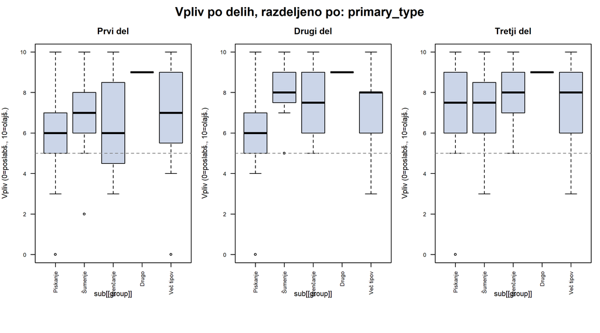

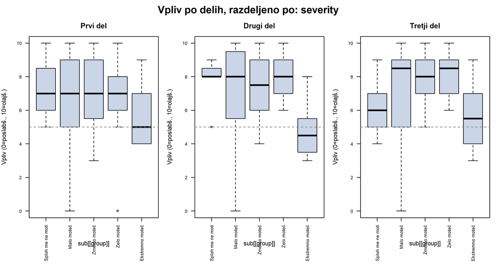

Vpliv na tinitus po delih in stopnji resnosti.

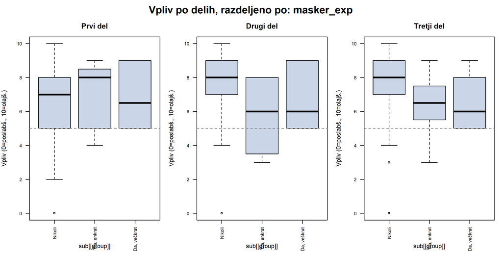

Vpliv na tinitus po delih in prejšnji izkušnji z maskerji.

## 5.7 Povezava med prijetnostjo in olajšanjem

Ali “lepo poslušati” pomeni tudi “manj tinitusa”? Spearmanov $\rho$ izračunan posebej za vsak del kompozicije:

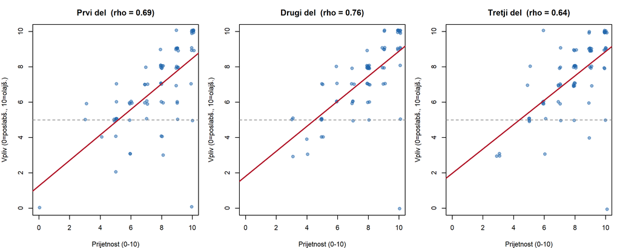

Razsevni diagram prijetnosti in vpliva na tinitus, po delih. Rdeča črta je linearna regresija, črtkana siva označuje nevtralno raven vpliva (5).

## 5.8 Kvalitativna analiza opisov

30 najpogostejših lem v opisih izkušnje (vse besedne vrste; brez italijanskih odgovorov).

| lemma | n |
| --- | --- |
| zvok | 50 |
| zelo | 47 |
| tinitus | 40 |
| prijetno | 38 |
| delo | 31 |
| prijeten | 22 |
| bolj | 21 |
| slišati | 19 |
| šumenje | 16 |
| najbolj | 13 |
| moteč | 12 |
| voda | 12 |
| zaspati | 12 |
| drug | 10 |
| glasba | 10 |
| sproščujoteti | 10 |
| tona | 10 |
| visok | 10 |
| mogoč | 9 |
| motiti | 8 |
| narava | 8 |
| močen | 7 |
| piskanje | 7 |
| poslušanje | 7 |
| sproščujoč | 7 |
| uho | 7 |
| všeč | 7 |
| dober | 6 |
| frekvenca | 6 |
| lep | 6 |

Leme, povezane z najvišjimi povprečnimi ocenami olajšanja (vsaj 5 dokumentov).

|  | lemma | n_docs | valence | impact |
| --- | --- | --- | --- | --- |
| 285 | sproščujoteti | 10 | 9.44 | 9.50 |
| 99 | lep | 6 | 9.67 | 9.50 |
| 152 | občasno | 5 | 7.50 | 9.00 |
| 383 | zamaskirati | 5 | 9.20 | 8.80 |
| 127 | najbolj | 13 | 8.92 | 8.46 |
| 130 | narava | 8 | 8.50 | 8.43 |
| 337 | umiriti | 6 | 8.50 | 8.33 |
| 299 | šumenje | 16 | 8.40 | 8.08 |
| 385 | zaspati | 12 | 9.40 | 8.00 |
| 124 | motiti | 8 | 8.25 | 8.00 |
| 54 | frekvenca | 6 | 8.67 | 8.00 |
| 368 | všeč | 7 | 8.14 | 7.83 |
| 37 | dober | 5 | 8.00 | 7.80 |
| 237 | prijetno | 36 | 8.25 | 7.77 |
| 283 | sproščujoč | 7 | 8.86 | 7.67 |

Leme, povezane z najnižjimi povprečnimi ocenami olajšanja (vsaj 5 dokumentov).

|  | lemma | n_docs | valence | impact |
| --- | --- | --- | --- | --- |
| 221 | pozornost | 5 | 9.00 | 2.50 |
| 214 | poslušanje | 7 | 8.50 | 3.57 |
| 60 | glasno | 5 | 5.20 | 3.75 |
| 354 | vibracija | 6 | 6.83 | 4.80 |
| 122 | moteč | 12 | 5.40 | 5.50 |
| 144 | nevtralno | 6 | 6.00 | 5.50 |
| 116 | močen | 7 | 6.14 | 5.86 |
| 312 | tinitus | 37 | 7.83 | 6.03 |
| 94 | konec | 5 | 8.00 | 6.50 |
| 325 | tona | 10 | 6.90 | 6.56 |
| 409 | zvok | 46 | 8.43 | 6.66 |
| 118 | mogoč | 9 | 6.38 | 6.75 |
| 375 | začetek | 5 | 8.20 | 6.75 |
| 333 | uho | 7 | 8.29 | 6.83 |
| 30 | delo | 28 | 7.58 | 7.00 |

## 5.9 Integrativni pregled (Sankey)

[interactive chart not shown]

Interaktivni 3D Sankey: podtip tinitusa -> resnost -> splošna ocena seje. Premaknite miško nad povezavo za prikaz števila opazovanj.

# 6 Razprava

**Omejitve.** Najpomembnejše omejitve so:

# 7 Zaključek

# 8 Priloge

## 8.1 A. Tabela vseh ocen po sejah

Povprečne ocene prijetnosti in vpliva po seji in delu (z velikostjo vzorca).

| Seja | Del | valence | impact |
| --- | --- | --- | --- |
| I | 1 | 7.33 (n=18) | 6.33 (n=18) |
| II | 1 | 8.08 (n=13) | 6.80 (n=10) |
| III | 1 | 8.00 (n=13) | 7.50 (n=10) |
| IV | 1 | 8.11 (n=14) | 7.56 (n=9) |
| V | 1 | 8.33 (n=12) | 6.75 (n=8) |
| VI | 1 | 8.40 (n=10) | 7.67 (n=6) |
| VII | 1 | 8.00 (n=6) | 7.00 (n=5) |
| VIII | 1 | 7.79 (n=19) | 5.57 (n=14) |
| I | 2 | 7.22 (n=18) | 7.50 (n=18) |
| II | 2 | 8.38 (n=13) | 7.90 (n=10) |
| III | 2 | 8.08 (n=13) | 7.38 (n=8) |
| IV | 2 | 8.85 (n=13) | 8.25 (n=8) |
| V | 2 | 7.67 (n=12) | 7.25 (n=8) |
| VI | 2 | 8.00 (n=9) | 7.17 (n=6) |
| VII | 2 | 7.17 (n=6) | 6.80 (n=5) |
| VIII | 2 | 8.05 (n=19) | 6.38 (n=13) |
| I | 3 | 7.50 (n=18) | 7.26 (n=19) |
| II | 3 | 7.85 (n=13) | 7.18 (n=11) |
| III | 3 | 8.00 (n=13) | 8.00 (n=10) |
| IV | 3 | 8.50 (n=14) | 7.67 (n=9) |
| V | 3 | 8.58 (n=12) | 7.50 (n=8) |
| VI | 3 | 8.89 (n=9) | 7.83 (n=6) |
| VII | 3 | 8.83 (n=6) | 7.80 (n=5) |
| VIII | 3 | 8.16 (n=19) | 6.54 (n=13) |

## 8.2 B. 4D Sankey: podtip x resnost x maskerji x doživetje

[interactive chart not shown]

Interaktivni 4D Sankey: podtip tinitusa -> resnost -> prejšnja uporaba maskerjev -> splošna ocena seje.

### 8.3.1 Seja I

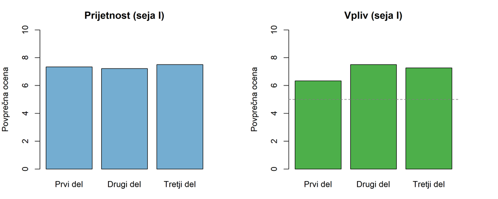

### 8.3.2 Seja II

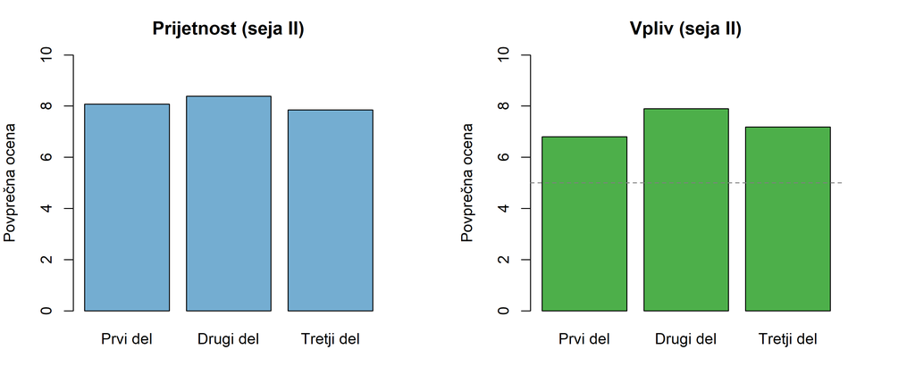

### 8.3.3 Seja III

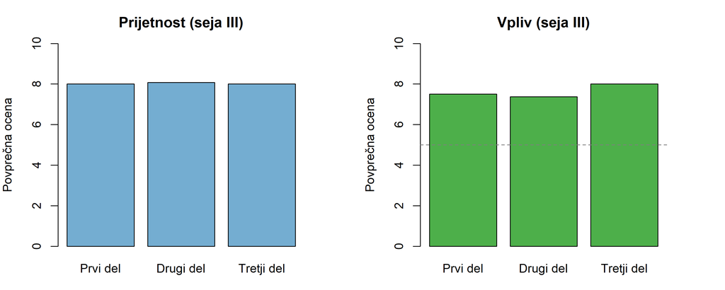

### 8.3.4 Seja IV

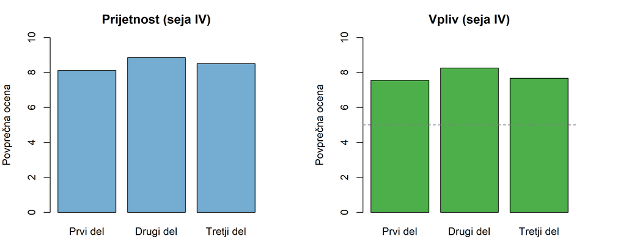

### 8.3.5 Seja V

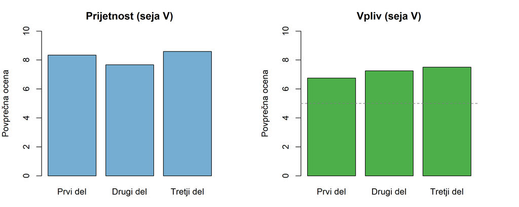

### 8.3.6 Seja VI

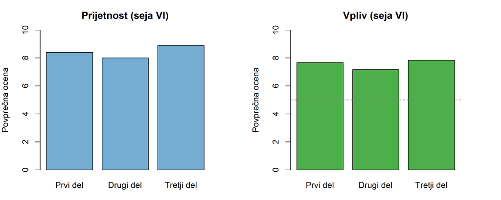

### 8.3.7 Seja VII

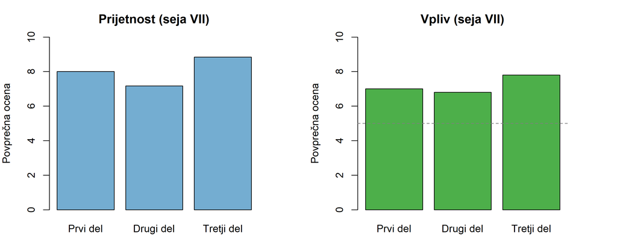

### 8.3.8 Seja VIII

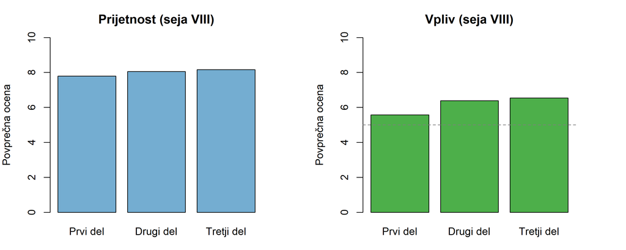

## 8.4 D. Matrika prisotnosti zvočnih elementov po delih

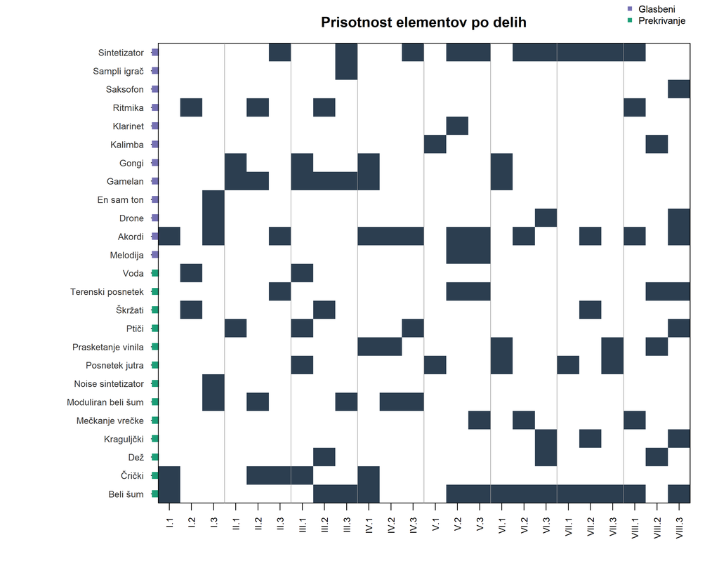

Prisotnost glasbenih elementov (vijolično) in elementov prekrivanja (zeleno) po posameznih delih kompozicij. Stolpci so deli v zaporedju seja.del; navpične sive črte ločujejo seje.

## 8.5 E. Polni opisi kompozicij (avtor: B. Simon)

```
OPISI KOMPOZICIJ
================

Spodnji opisi so avtorjev opis zvočne vsebine vsakega dela vsake seje.
Iz teh opisov je bila izpeljana binarna kodirna shema v
data/raw/composition_coding.csv.

----------------------------------------------------------------
ZVOČNI OBJEM 1 (seja I, 24. 2. 2026)
----------------------------------------------------------------
Prvi del:  akordi fade in / fade out
           masker: črički in malo belega šuma
Drugi del: ritmične sekvence
           maskerji: zvok vode in kasneje škržati
Tretji del: drone akordi in potem en ton
           maskerji: umetni maskerji (moduliran beli šum
           in noise sintetizatorja na visokih frekvencah)

----------------------------------------------------------------
ZVOČNI OBJEM 2 (seja II, 3. 3. 2026)
----------------------------------------------------------------
Prvi del:  Gamelan indonezijski orkester, gongi počasno in redko
           masker: zvoki narave (ptičev)
Drugi del: Gamelan ritmično
           masker: črički in moduliran beli šum
Tretji del: akordi na sintetizator fade in fade out
           maskerji: črički in terenski posneti

----------------------------------------------------------------
ZVOČNI OBJEM 3 (seja III, 10. 3. 2026)
----------------------------------------------------------------
Prvi del:  Gamelan gongi
           maskerji: posnetek jutra (ptiči), čričkov, vode
Drugi del: Gamelan drugačen, sekvence
           maskerji: dež, škržati, beli šum
Tretji del: Sintetizator sekvenca in gamelan, sampli igrač
           masker: mešanica belih šumov

----------------------------------------------------------------
ZVOČNI OBJEM 4 (seja IV, 17. 3. 2026)
```

[output cut: 42 more lines]

```
           masker: vrečka, beli šum
Drugi del: Kalimba in efekti
           masker: terenski posnetek Lijak, prasketanje vinila,
                   posnetek dežja
Tretji del: Dolgi toni saksofon, drone akordi
           masker: kraguljčki, beli šum, posnetek Nadiže, ptičje petje

----------------------------------------------------------------
SPLOŠNA OPOMBA AVTORJA
----------------------------------------------------------------
Modulirani beli šum sem dodajal in odvzemal po okusu, da se je
stvar premikala in da sem pokril čimveč frekvenc, ki bi
zamaskirale tinitus. Ta sprememba se je dogajala večkrat na 15-min
sklop seanse, ker je bilo poslušanje enega samega maskerja več kot
5 min utrujajoče.
```

## 8.7 G. Reproducibilnost

Celotna koda je dostopna v projektnem repozitoriju. Glavni skripti:

- `R/00_setup.R` — knjižnice in pomožne funkcije
- `R/01_clean_data.R` — predobdelava surovih podatkov
- `R/02_plots.R` — risarske funkcije
- `R/03_textanalysis.R` — analiza prostih besedil
- `R/04_signup_check.R` — analiza listov prisotnosti
- `R/05_composition.R` — analiza po zvočnih elementih

Poročilo (`report/porocilo.Rmd`) se preprosto preveže (knit) z izvedbo `rmarkdown::render("report/porocilo.Rmd")`.